# Lab03

Yifei Liu

28/03/2021

## Task 1: Generate Data

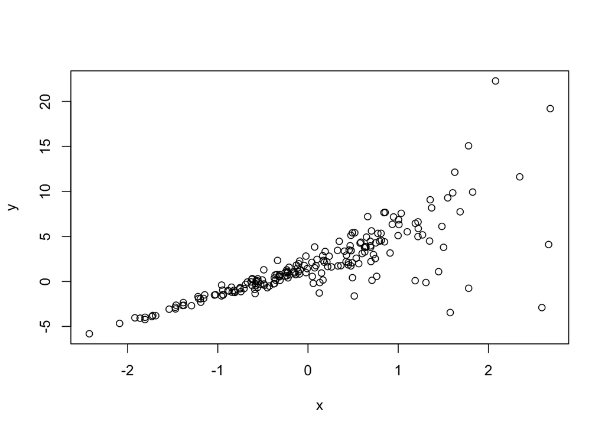

```r
library(sandwich)

set.seed(567697779)
n <- 200
x <- rnorm(n)
residual_std <- exp(x)
y <- 1.5+3*x + residual_std*rnorm(n)

plot(x, y)
```

Comment: y appears to be have a linear relationship with x, with the standard error increasing exponentially as x increases.

## Task 2: Fitting linear regression model.

```r
# Fit the linear regression model
fit <- lm(y ~ x)
# Summary of fitted model
summary(fit)
```

```
##
## Call:
## lm(formula = y ~ x)
##
## Residuals:
##      Min       1Q   Median       3Q      Max
## -12.8403  -0.4213   0.0965   0.4432  13.9849
##
## Coefficients:
##             Estimate Std. Error t value Pr(>|t|)
## (Intercept)   1.6539     0.1667   9.923   <2e-16 ***
## x             3.1944     0.1743  18.327   <2e-16 ***
## ---
## Signif. codes:  0 '***' 0.001 '**' 0.01 '*' 0.05 '.' 0.1 ' ' 1
##
## Residual standard error: 2.353 on 198 degrees of freedom
## Multiple R-squared:  0.6291, Adjusted R-squared:  0.6272
## F-statistic: 335.9 on 1 and 198 DF,  p-value: < 2.2e-16
```

```r
# Calculate the 95% confidence interval
1.96 * 0.1743
```

```
## [1] 0.341628
```

Comments:  
- The standard error of coefficient of x is 0.1743.  
- The 95% confidence interval is 3.19 ± 0.34. (Rounded to nearest 2d.p.)  
- The p-value suggest very strong evidence that x and y are correlated, as the value is extremely close to 0 (<2e-16 ***).  
(A lower p-value suggests there is strong evidence x is related to y.)

P-value tells is whether there is a relationship or not, confidence interval quantifies how strong that relationship is.  
In this case, we can observe strong evidence that x and y are correlated, and we are 95% confident that y will be in the range of [3.19x ± 0.34].

## Task 3: Sandwich estimator

```r
vcovHC(fit, type = 'HC') # covariance matrix
```

```
##             (Intercept)          x
## (Intercept)  0.02234324 0.04429502
## x            0.04429502 0.11191689
```

```r
sandwich_se <- sqrt(diag(vcovHC(fit, type = 'HC'))) # standard error

sandwich_se
```

```
## (Intercept)           x
##   0.1494765   0.3345398
```

```r
# calculate confidence interval
1.96 * 0.3345398
```

```
## [1] 0.655698
```

```r
# calculate p-value
2*(1-pt(18.327, df = 198, lower.tail = TRUE))
```

```
## [1] 0
```

Comments:  
- 95% confidence interval: 3.19 ± 0.66 (About twice as much as previosu value.) - p-value: 0 (Very strong evidence of x-y correlation)

## Task 4: Comparison & Comments

The summary from fitting the linear regression model predicted with 95% confidence for y to be in the range of [3.19x ± 0.34] , with a p-value of [<2e-16 ***].  
The sandwich estimator predicted with 95% confidence for y to be in the range of [3.19x ± 0.66], with a p-value of [0].

There was practically no difference in the p-value. This means we are just as sure that x and y are correlated with each other.  
The only difference in this specific example was that the sandwich estimator predicted a larger standard deviation, which resulted in a wider 95% confidence interval.

Yifei Liu